# Problem Set 1 - Board Games

SI 544 Instruction Team

9/27/2019

# Problem Set 1 - Visualizations and Tidy Data

The total score for this assignment will be 100 points, consisting of: - 90 pts: Homework Questions - 10 pts: Overall quality of spelling, grammar, punctuation, etc. of written sentences.

As in lecture and discussion, there are several ways to approach and answer these questions! There may not be a “best solution”, but instead a variety of ways to interpret and analyze a given task. Be thoughtful in your responses below your code to explain why you chose the methods and representations in your analysis when prompted for a response.

For further reference regarding quality writing, feel free to refer to Strunk & White’s Elements of Style: https://drive.google.com/file/d/1L0P7xJwjUGBvyb49mL3dw1Bt7hzRTiTl/view?usp=sharing

## The Data

Our data set comes from the popular board game site https://boardgamegeek.com, a resource used for reviewing and discussing board games. Contemporary board games are a personal interest of mine (Jordan)! They provide a face to face experience rich in analytic opportunities and can spur discussions about UX design in the rules, materials, and game mechanics. Board Game Geek (BGG) serves as a hub for players to come together and gather data for other players to reference as they search out new and novel play experiences. This data set can help reveal some design choices that are favored by the board game community at large.

(If you want to go deep talking board games, feel free to talk to me outside of class! -Jordan)

Copy the file ‘bgg_2018.csv’ from the read only folder into your working directory, fill in your name into the string assigned to *MY_UNIQNAME* , then execute the code block to load the packages into your environment.

```r
MY_UNIQNAME = "Tabbie"

# Initial setup for our environment
library(tidyverse)
```

```r
library(ggplot2)

# Reading the file in from your working directory
data <- read_csv('bgg_2018.csv')
```

### Question 1 (10 points)

Describe the shape of the distribution of ratings for the games in the dataset. (Do this for both avg_rating and geek_rating) Find the mean and median for avg_rating and geek_rating, then discuss which metric is an appropriate measure of the center for each distribution

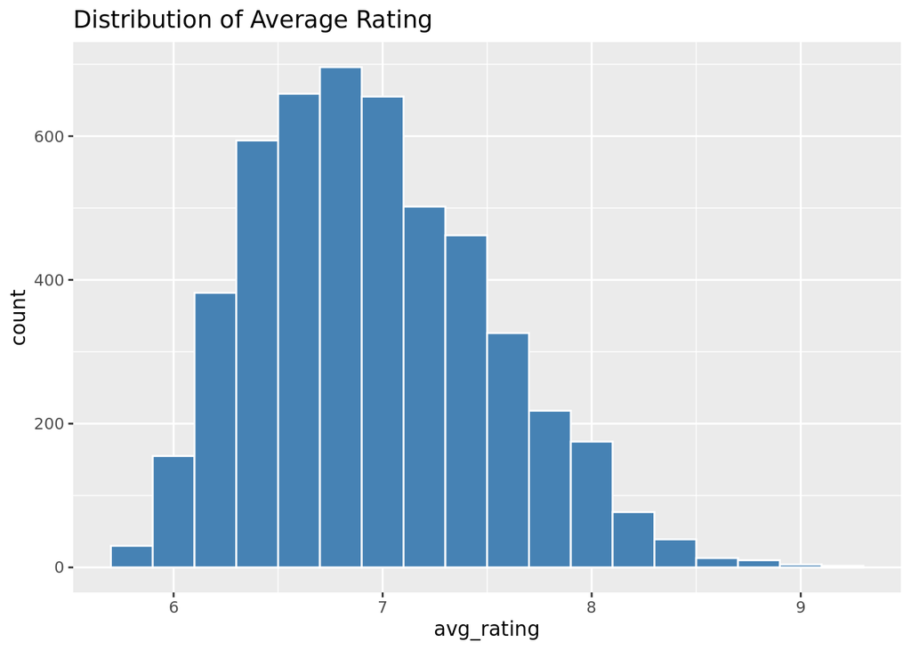

```r
ggplot(data = data, mapping = aes(x = avg_rating)) + geom_histogram(binwidth = 0.2, fill='steelblue', colour = 'white') +
  labs(title = "Distribution of Average Rating")
```

```r
data %>% summarise(Mean = mean(avg_rating), Median = median(avg_rating))
```

```
## # A tibble: 1 x 2
##    Mean Median
##   <dbl>  <dbl>
## 1  6.96   6.90
```

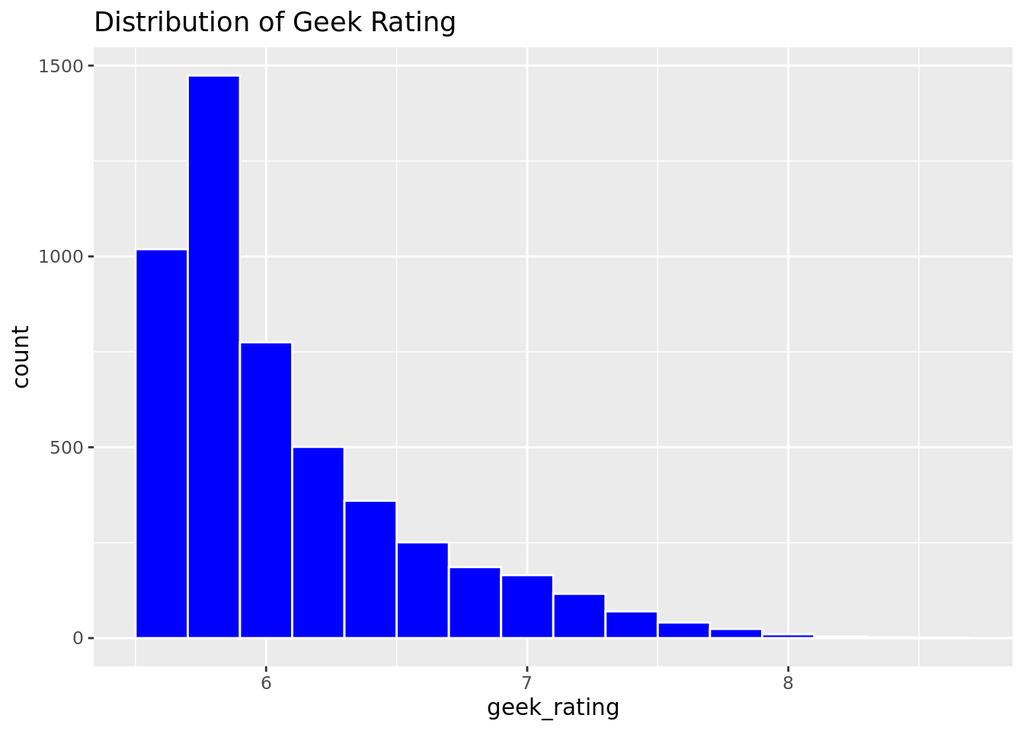

```r
ggplot(data = data, mapping = aes(x = geek_rating)) + geom_histogram(binwidth = 0.2, fill = 'blue', colour = 'white') +
  labs(title = "Distribution of Geek Rating")
```

```r
data %>% summarise(Mean = mean(geek_rating), Median = median(geek_rating))
```

```
## # A tibble: 1 x 2
##    Mean Median
##   <dbl>  <dbl>
## 1  6.08   5.90
```

#### Q1 Response:

According to me, mean is the better measure of the center of each distribution as it is inclusive of all the values in the dataset, i.e; both highest and lowest values and those in between.

### Question 2 (5 points)

The original data set includes some columns that will not be useful for our analysis. Create a new dataframe that **does not** include the game id, the bgg url, and the image url columns. Use the cleaned data frame to create another data frame containing the top 500 ranked games and assign it to a separate variable. Note: This can be accomplshed in one step using pipes!

```r
 Top_500_Ranked = data %>% select(-game_id,-bgg_url, -image_url) %>% filter(rank <= 500)
```

### Question 3 (20 points)

Within the top 500 games there is a large variety of games with different player counts. How do the ratings of games appear to differ between games with different maximum player counts? Give both a numeric summary and a visualization to demonstrate the average rating, spread, and number of games for each maximum player count. What set of maximum player counts appear to have higher ratings?

(For the rest of the assignment, use avg_rating for any prompts invloving game rating)

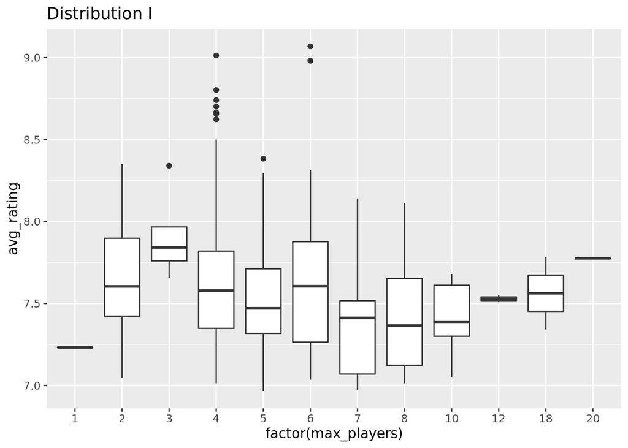

```r
Max_player = Top_500_Ranked %>% group_by(max_players) %>% summarise(average_rating = mean(avg_rating), spread = sd(avg_rating), number = n())

ggplot(data = Top_500_Ranked, mapping = aes(x = factor(max_players), y = avg_rating)) + geom_boxplot() + labs(title = 'Distribution I')
```

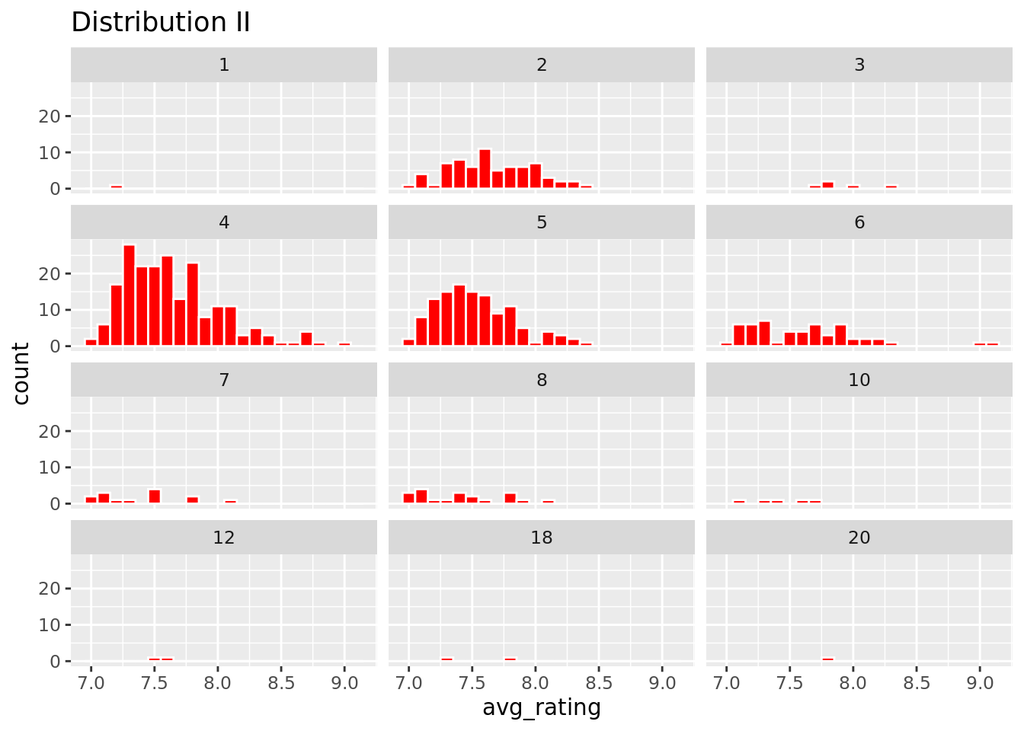

```r
ggplot(data = Top_500_Ranked, mapping = aes(x = avg_rating)) + geom_histogram(binwidth = 0.1, colour = 'white', fill = 'red') + facet_wrap(~max_players, nrow = 4) + labs(title = 'Distribution II')
```

### Question 4 (15 points)

Which game is owned by the most BGG users and what rank is it? How does the player count and play time for this game compare to other games in the top 500? Discuss your findings below the code block showing your code that found the values.

```r
Sort_arrange = Top_500_Ranked %>% arrange(desc(owned))
```

#### Q4 Response:

Catan is owned by most BGG users and it’s rank is 272. The average time of this game is approximately double when compared to other successive games in the order. The player count of this game is two to five players less when compared to other successive games in thee order.

### Question 5 (15 points)

Does there appear to be a relationship between game weight (https://boardgamegeek.com/wiki/page/Weight) and the number of players? Write your thoughts below the code block containing numerical analysis or a visualization. (You may find a boxplot helpful here)

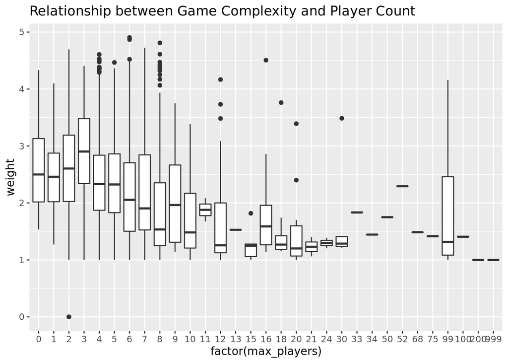

```r
Relationship_player = data %>% group_by(max_players) %>% summarise(average_weight = mean(weight), spread = sd(weight), number = n())

ggplot(data = data, mapping = aes(x = factor(max_players), y = weight)) + geom_boxplot()+ labs(title = 'Relationship between Game Complexity and Player Count')
```

#### Q5 Response:

As seen in the boxplot above, the game weight decreases with increase in the number of players.

### Question 6 (15 points)

Create a plot showing the number of board games released by year. What trends do you notice?

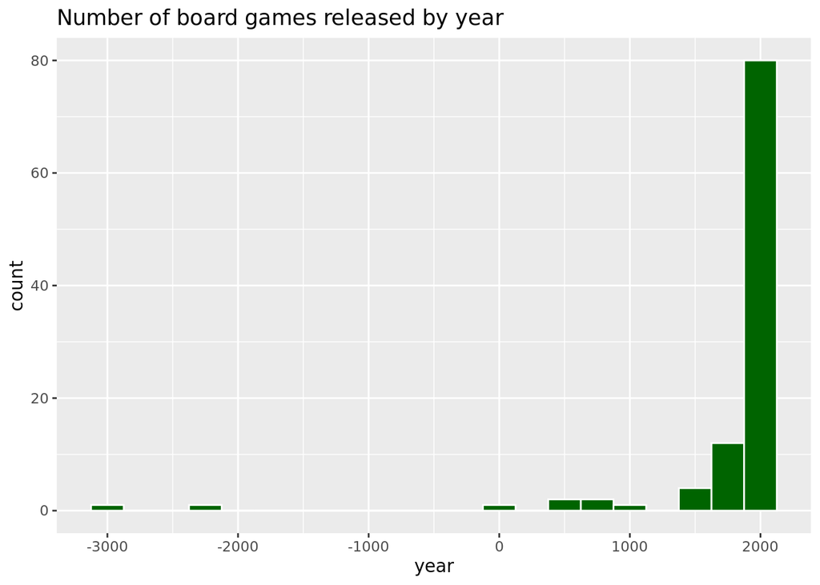

```r
by_year = data %>% group_by(year) %>% summarise(number = n())
ggplot(data = by_year, mapping = aes(x = year)) + geom_histogram(binwidth = 250, colour = 'white', fill = 'darkgreen') + labs(title = 'Number of board games released by year')
```

## Question 7 (10 points)

Which games have more votes than owners? Create a new column in your top 500 dataframe labeled vote_own_ratio expressing the ratio of votes to owners.

```r
Game_voters = Top_500_Ranked %>% mutate(vote_own_ratio = num_votes/owned) %>% arrange(desc(vote_own_ratio))
```